# Curva de Laffer: Una introducción con R

Kamal Romero

Abril de 2018

A cotinuación se deriva una curva de Laffer para un impuesto al trabajo. Partimos de un mercado de trabajo clásico muy básico.

# 1 Entorno

Del lado de la demanda empleamos una función Cobb-Douglas estándar

$Y=AK^{\frac{1}{3}}N^{\frac{2}{3}}$

obteniendo una demanda de trabajo convencional

$DN=\bigg(\frac{2}{3}\frac{A}{w}\bigg)^3K$

Del lado de la oferta usamos una función de utilidad simple

$U=\frac{c^\gamma}{\gamma}-N$

sujeta a la restricción de presupuesto

$C=(1-\tau_l)wN$

a partir de la cual se obtiene la siguiente función de oferta de trabajo

$ON=[(1-\tau_l)w]^{(\frac{\gamma}{1-\gamma})}$

Un incremento en el impuesto al trabajo $\tau_l$ reduce la oferta de trabajo y por ende, la producción de la economía.

Para determinar el salario y empelo de equilibrio igualamos oferta y demanda

$\bigg(\frac{2}{3}\frac{A}{w}\bigg)^3K=[(1-\tau_l)w]^{\frac{\gamma}{1-\gamma}}$

Asumiendo que $\gamma=0,5$ el salario de equilibrio viene dado por

$w=\bigg[ \bigg(\frac{2}{3}A\bigg)^3\frac{K}{1-\tau_l} \bigg]^{\frac{1}{4}}$

Al aumentar el impuesto al trabajo $\tau_l$ cae la oferta de trabajo y sube el salario de equilibrio a la vez que disminuye el nivel de empleo.

La recaudación viene dada por el tipo impositivo $\tau_l$ multiplicado por el total de rentas salariales $W\times N$

$\tau_l \times W \times N$

# 2 Construyendo una Curva de Laffer

Asignamos valores a $A=1$ y $K=400$ en la expresión , y calculamos la recaudación para cada tipo $\tau$

Cargamos los paquetes necesarios

```r
PAQUETES <- c("pacman")
inst <- match(PAQUETES, .packages(all=TRUE))
need <- which(is.na(inst))
if (length(need) > 0) install.packages(PAQUETES[need])

pacman::p_load(ggplot2, reshape2, shiny)
```

## 2.1 Funciones

Primero definimos una serie de funciones necesarias para el cálculo

Función que define el exceso de demanda en el mercado de trabajo. Posteriormente pasamos esta función a un solver no lineal para encontrar el salario de equilibrio

```r
f1 <- function(w, tl, alfa  = 1/3,  K = 400,   A = 1,   gamma.l = 0.5){
  # Calcula el exceso de demanda del mercado de trabajo
  # necesario para encontrar el salrio de equilibrio
  #
  # Args:
  #   w: salario
  #   tl: impuesto al trabajo
  #   alfa: participacion del capital en la funcion de produccion (default=1/3)
  #   K: stock de capital (default=400)
  #   A: productividad total de los factores TFP (default=1)
  #   gamma.l: elasticidad de sustitucion del consumo (default=0.5)
  #
  # Returns:
  #   ed: El exceso de demanda en el mercado de trabajo definido como
  #   la  diferencia entre demanda y oferta de trabajo

  # Consideramos solo funciones de produccion con rendimientos
  # constantes a escala
    if (alfa > 1 | alfa < 0) {
    stop(" 'alfa' debe ser un numero entre cero y uno", call. = FALSE)
  }

  #Exceso de demanda
  ed <- (demanda_trabajo(w, alfa, K, A)-oferta_trabajo(w, tl, gamma.l))

}
```

Función de demanda

```r
demanda_trabajo <- function(w, alfa  = 1/3,  K = 400,   A = 1){
  # Calcula la demanda de trabajo
  #
  # Args:
  #   w: salario
  #   alfa: participacion del capital en la funcion de produccion (default=1/3)
  #   K: stock de capital (default=400)
  #   A: productividad total de los factores TFP (default=1)
  #
  # Returns:
  #   dl: Demanda de trabajo obtenida a partir de una funcion de
  #   produccion Cobb-Douglas

  # Consideramos solo funciones de produccion con rendimientos
  # constantes a escala
  if (alfa > 1 | alfa < 0) {
    stop(" 'alfa' debe ser un numero entre cero y uno", call. = FALSE)
  }

  dl <- (((1-alfa)*(A/w))^3)*K
}
```

Función de oferta

```r
oferta_trabajo <- function(w, tl,  gamma.l = 0.5){
  # Calcula la oferta de trabajo
  #
  # Args:
  #   w: salario
  #   tl: impuesto al trabajo
  #   gamma.l: elasticidad de sustitucion del consumo (default=0.5)
  #
  # Returns:
  #   ol: Oferta de trabajo obtenidad a partir de una funcion de
  #   utilidad U=c^gamma/gamma-N sujeta a una restricción de
  #   presupuesto igual a C=(1-t_l)wN

  ol <- ((1-tl)*w)^(gamma.l/(1-gamma.l))
}
```

Función de producción

```r
produccion <- function(N, alfa  = 1/3,  K = 400,   A = 1){
  # Calcula la produccion
  #
  # Args:
  #   N: empleo que vacia el mercado de trabajo
  #   alfa: participacion del capital en la funcion de produccion (default=1/3)
  #   K: stock de capital (default=400)
  #   A: productividad total de los factores TFP (default=1)
  #
  # Returns:
  #   y: nivel de produccion obtenida a partir de una funcion de
  #   produccion Cobb-Douglas

  # Consideramos solo funciones con rendimientos constantes a escala
  if (alfa > 1 | alfa < 0) {
    stop(" 'alfa' debe ser un numero entre cero y uno", call. = FALSE)
  }

  y <- A*K^alfa*N^(1-alfa)
}
```

## 2.2 Construcción del data frame con los datos

Definimos una matriz inicial a ser rellenada

```r
tabla <- matrix(ncol = 5, nrow = length(seq(0,0.99,0.01)))
```

Hacemos un bucle que genera los datos de recaudación, empleo, salario y producción para cada tipo t

```r
contador <- 1
for(i in seq(0,0.99,0.01)){
  tabla[contador,1] <- i
  w <- uniroot(f1,c(0.1,20),tl=i)$root
  tabla[contador,2] <- w
  N <- demanda_trabajo(w)
  tabla[contador,3] <- N
  R <- i*w*N
  tabla[contador,4] <- R
  Y <- produccion(N)
  tabla[contador,5] <- Y
  contador <- contador + 1
}
```

Convertimos la matriz a data frame y nombramos las columnas

```r
tabla.1 <- data.frame(tabla)

colnames(tabla.1) <- c('Impuesto','Salario','Empleo','Recaudacion','Produccion')
```

## 2.3 Gráficos

Realizamos un grupo de gráficos. Primero el gráfico de la Curva de Laffer

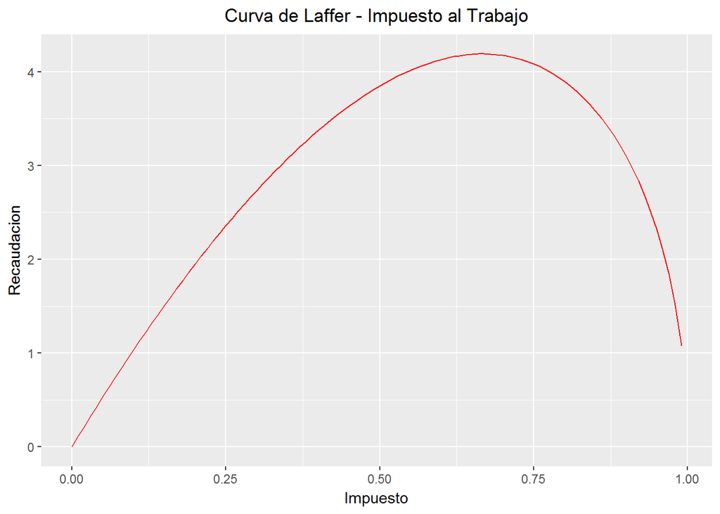

```r
l1 <- ggplot(data = tabla.1, aes(x=Impuesto,y=Recaudacion)) +
  geom_line(col="red") +
  ggtitle("Curva de Laffer - Impuesto al Trabajo") +
  theme(plot.title = element_text(hjust = 0.5))  #Esto es para centrar el título
l1
```

Se aprecia la relación no monótona que caracteriza a dicha relación, la recaudación incrementa con el tipo hasta cierto punto a partir del cual desciende.

A nivel general la recaudación $T$ se define como el tipo $\tau$ multiplicado por la base impositiva $B(\tau)$ la cual depende del tipo.

$T = \tau \times B(\tau)$

Al subir el tipo disminuye la base, por lo que tenemos dos efectos en direcciones contrarias

Según nuestra definición de recaudación $(\tau_l \times W \times N)$, tenemos tres fuerzas operando, sabemos que cuando sube el tipo disminuye la oferta de trabajo, manteniendo todo lo demás constante sube el salario y disminuye el nivel de empleo. Veamos el comportamiento de cada concepto

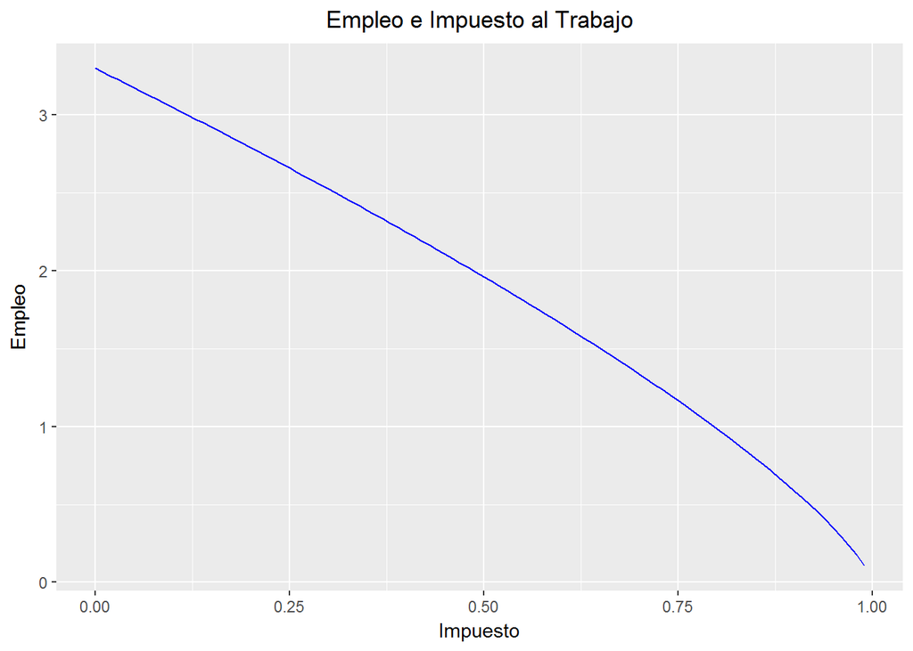

```r
l2 <- ggplot(data = tabla.1, aes(x=Impuesto,y=Empleo)) +
  geom_line(col="blue") +
  ggtitle("Empleo e Impuesto al Trabajo") +
  theme(plot.title = element_text(hjust = 0.5))  #Esto es para centrar el título
l2
```

En el gráfico anterior se observa como el empleo se reduce ante un impuesto al trabajo. Veamos a continuación como se comporta el salario

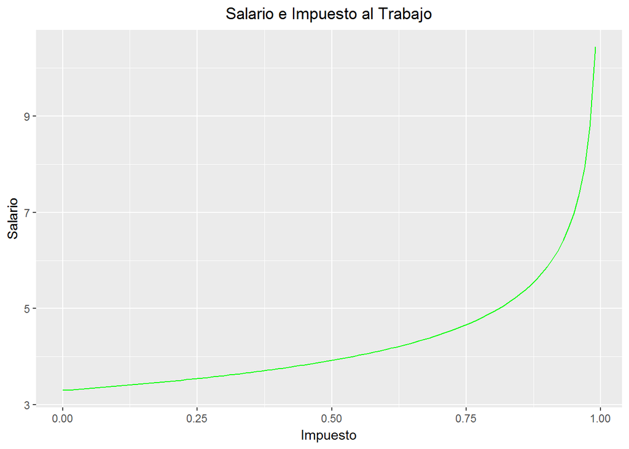

```r
l3 <- ggplot(data = tabla.1, aes(x=Impuesto,y=Salario)) +
  geom_line(col="green") +
  ggtitle("Salario e Impuesto al Trabajo") +
  theme(plot.title = element_text(hjust = 0.5))  #Esto es para centrar el título
l3
```

Como era de esperar aumenta el salario, se observa como para valores muy altos del impuesto la tasa a la que aumenta el salario se acelera notablemente.

Dada la caída del empleo manteniendo el capital constante, la producción desciende como se observa en el siguiente gráfico

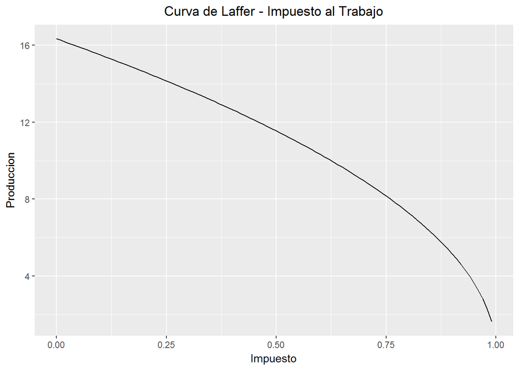

```r
l4 <- ggplot(data = tabla.1, aes(x=Impuesto,y=Produccion)) +
  geom_line() +
  ggtitle("Curva de Laffer - Impuesto al Trabajo") +
  theme(plot.title = element_text(hjust = 0.5))  #Esto es para centrar el título
l4
```

Mostramos todos los gráficos juntos, para eso hay que manipular algo el data frame de manera que la libreria `ggplot2` lo lea de manera correcta

Colocamos la tabla en formaro flat para poder hacer el facet

```r
tabla.flat <- melt(tabla.1, id.vars = c('Impuesto'))
```

Creamos un factor para que en el gráfico aparezca el facet en el orden que yo quiero, el cual viene dado por la jerarquía del factor

```r
tabla.flat$facet <- factor(tabla.flat$variable, levels = c('Recaudacion','Empleo','Produccion','Salario'))
```

Y ya estamos preparados para realizar el gráfico

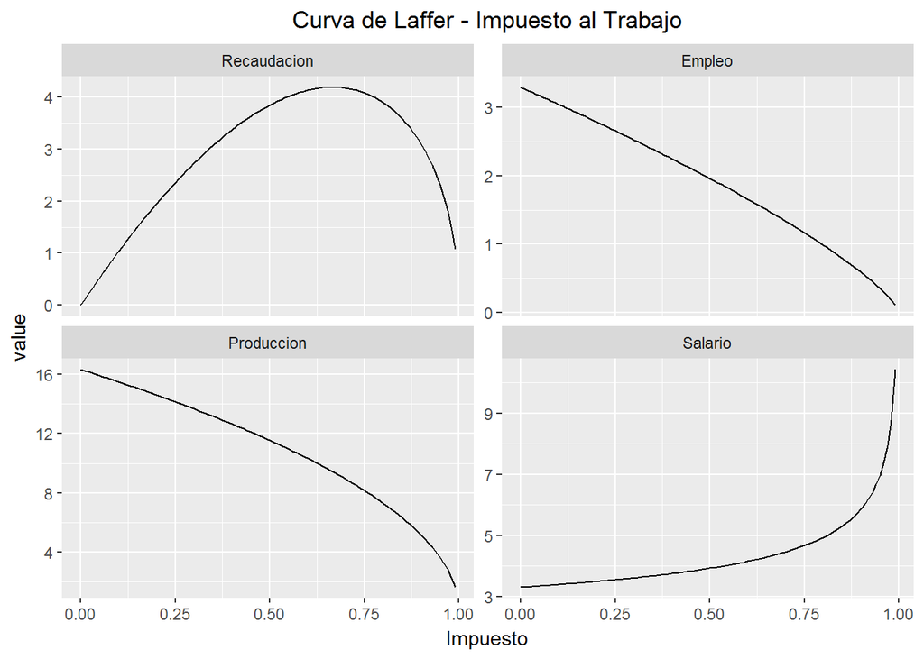

```r
lf <- ggplot(data = tabla.flat, aes(x=Impuesto, y=value)) +
  geom_line() +
  facet_wrap(~facet, scales = "free_y") +
  ggtitle("Curva de Laffer - Impuesto al Trabajo") +
  theme(plot.title = element_text(hjust = 0.5))  #Esto es para centrar el título
lf
```